# Data 624 Homework 2

Steven Gonzalez

2/16/2025

## Load Packages

```r
library(fpp3)
library(seasonal)
library(USgas)
```

## Exercise 1

Consider the GDP information in global_economy. Plot the GDP per capita for each country over time. Which country has the highest GDP per capita? How has this changed over time?

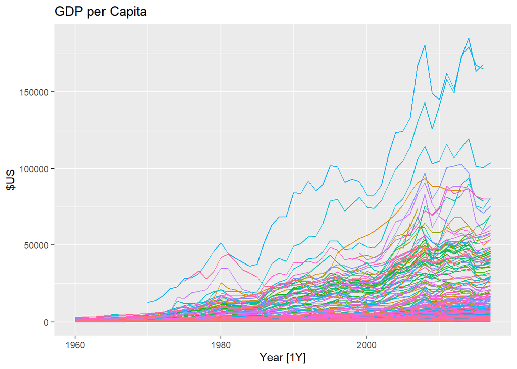

```r
autoplot(global_economy, GDP/Population) +
  labs(title= "GDP per Capita", y = "$US") +
  theme(legend.position = "none")
```

The above plot illustrates the GDP per capita for each country over time. The legend has been removed because the large number of countries was rendering the graph imperceptible. In order to then identify the country with the highest GDP per capita, the code below was performed.

```r
global_economy %>%
  mutate(GDP_capita = GDP/Population) %>%
  arrange(desc(GDP_capita))
```

```
## # A tsibble: 15,150 x 10 [1Y]
## # Key:       Country [263]
##    Country Code   Year    GDP Growth   CPI Imports Exports Population GDP_capita
##    <fct>   <fct> <dbl>  <dbl>  <dbl> <dbl>   <dbl>   <dbl>      <dbl>      <dbl>
##  1 Monaco  MCO    2014 7.06e9  7.18     NA      NA      NA      38132    185153.
##  2 Monaco  MCO    2008 6.48e9  0.732    NA      NA      NA      35853    180640.
##  3 Liecht… LIE    2014 6.66e9 NA        NA      NA      NA      37127    179308.
##  4 Liecht… LIE    2013 6.39e9 NA        NA      NA      NA      36834    173528.
##  5 Monaco  MCO    2013 6.55e9  9.57     NA      NA      NA      37971    172589.
##  6 Monaco  MCO    2016 6.47e9  3.21     NA      NA      NA      38499    168011.
##  7 Liecht… LIE    2015 6.27e9 NA        NA      NA      NA      37403    167591.
##  8 Monaco  MCO    2007 5.87e9 14.4      NA      NA      NA      35111    167125.
##  9 Liecht… LIE    2016 6.21e9 NA        NA      NA      NA      37666    164993.
## 10 Monaco  MCO    2015 6.26e9  4.94     NA      NA      NA      38307    163369.
## # ℹ 15,140 more rows
```

```r
global_economy %>%
  mutate(GDP_capita = GDP/Population) %>%
  filter(Code == "MCO" | Code == "LIE", Year == 2016) %>%
  arrange(desc(GDP_capita))
```

```
## # A tsibble: 2 x 10 [1Y]
## # Key:       Country [2]
##   Country  Code   Year    GDP Growth   CPI Imports Exports Population GDP_capita
##   <fct>    <fct> <dbl>  <dbl>  <dbl> <dbl>   <dbl>   <dbl>      <dbl>      <dbl>
## 1 Monaco   MCO    2016 6.47e9   3.21    NA      NA      NA      38499    168011.
## 2 Liechte… LIE    2016 6.21e9  NA       NA      NA      NA      37666    164993.
```

The above tsibbles indicate Monaco to be the country with the highest GDP per capita; a trend that has held true since at least the 1970’s with Liechtenstein coming in at a close second.

## Exercise 2

For each of the following series, make a graph of the data. If transforming seems appropriate, do so and describe the effect.

United States GDP from global_economy. Slaughter of Victorian “Bulls, bullocks and steers” in aus_livestock. Victorian Electricity Demand from vic_elec. Gas production from aus_production.

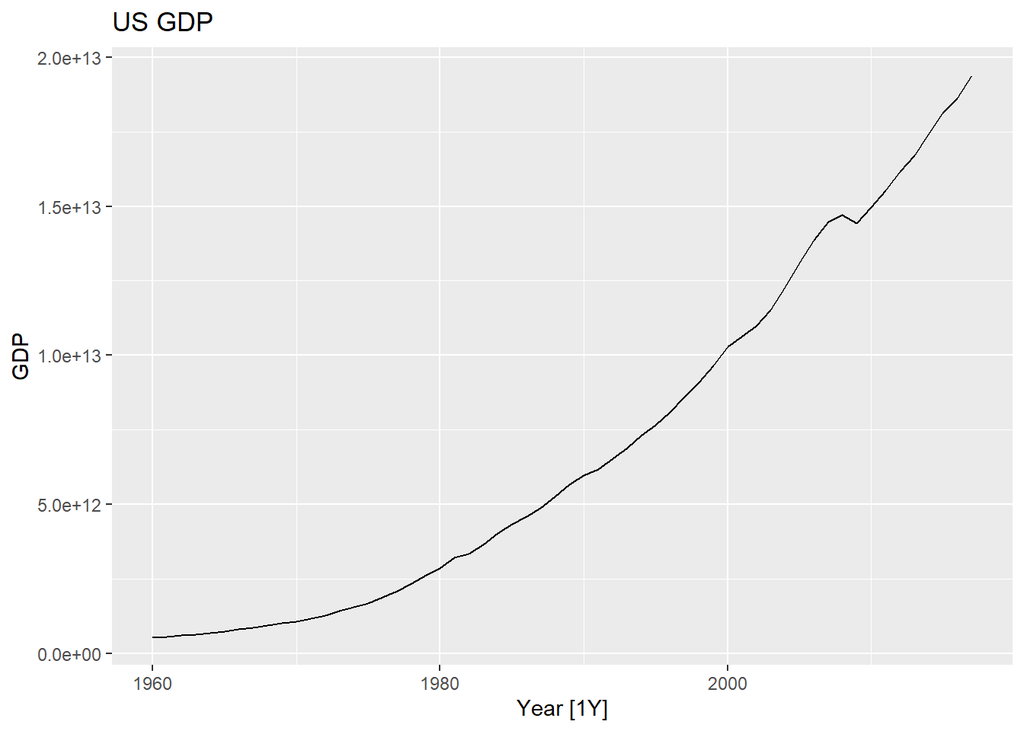

```r
autoplot(global_economy %>%
           filter(Country == "United States"), GDP) +
  labs(title= "US GDP")
```

The plot of United States GDP from global_economy is pretty smooth and shouldn’t require any transforming since there isn’t any variation that would need to be made uniform.

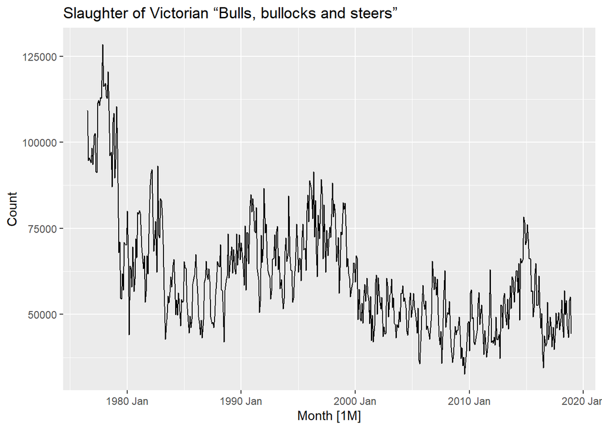

```r
autoplot(aus_livestock %>%
           filter(Animal == "Bulls, bullocks and steers",
                  State == "Victoria"), Count) +
  labs(title= "Slaughter of Victorian “Bulls, bullocks and steers”")
```

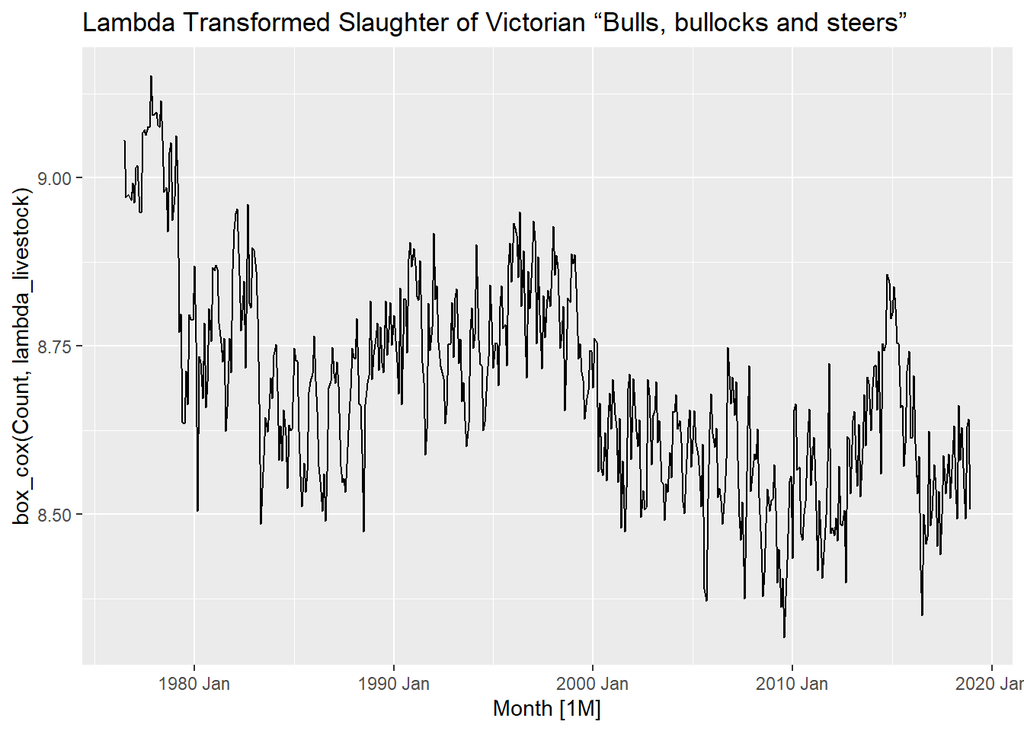

```r
lambda_livestock <- aus_livestock %>%
  filter(Animal == "Bulls, bullocks and steers",
                  State == "Victoria") %>%
  features(Count, features = guerrero) %>%
  pull(lambda_guerrero)

aus_livestock %>%
  filter(Animal == "Bulls, bullocks and steers",
         State == "Victoria") %>%
  autoplot(box_cox(Count, lambda_livestock)) +
  labs(title= "Lambda Transformed Slaughter of Victorian “Bulls, bullocks and steers”")
```

The plot of Slaughter of Victorian “Bulls, bullocks and steers” in aus_livestock did require some transforming since the variation was not constant throughout. Interestingly enough, the value of lambda recommended using the guerrero feature was negative. The plot did seem more uniform after transforming.

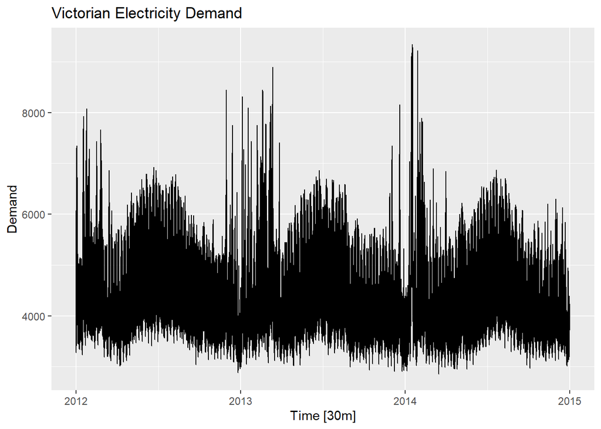

```r
autoplot(vic_elec, Demand) +
  labs(title = "Victorian Electricity Demand")
```

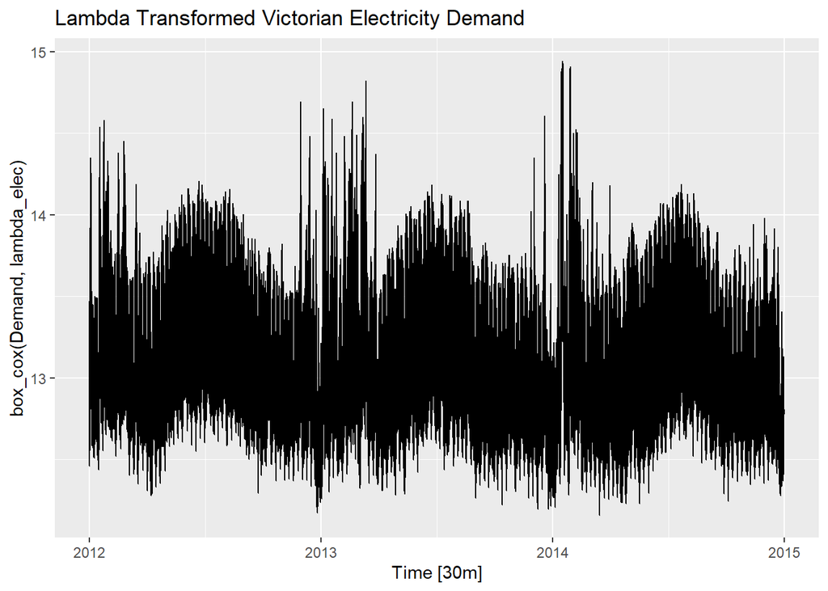

```r
lambda_elec <- vic_elec %>%
  features(Demand, features = guerrero) %>%
  pull(lambda_guerrero)

vic_elec %>%
  autoplot(box_cox(Demand, lambda_elec)) +
  labs(title = "Lambda Transformed Victorian Electricity Demand")
```

The plot of Victorian Electricity Demand from vic_elec was clearly seasonal and so one would expect the variation to also change depending on the time of year. A transformation was able to squeeze in the degree of variation slightly, however, not enough to make a notable difference. When it comes to repetitive data sets such as this one, there doesn’t seem to be such an obvious benefit to transformation.

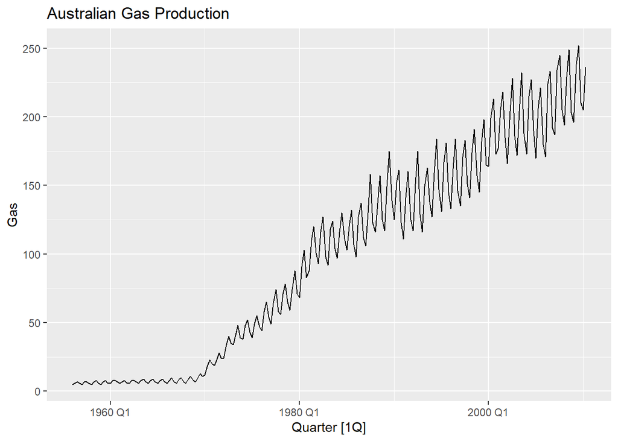

```r
autoplot(aus_production, Gas) +
  labs(title= "Australian Gas Production")
```

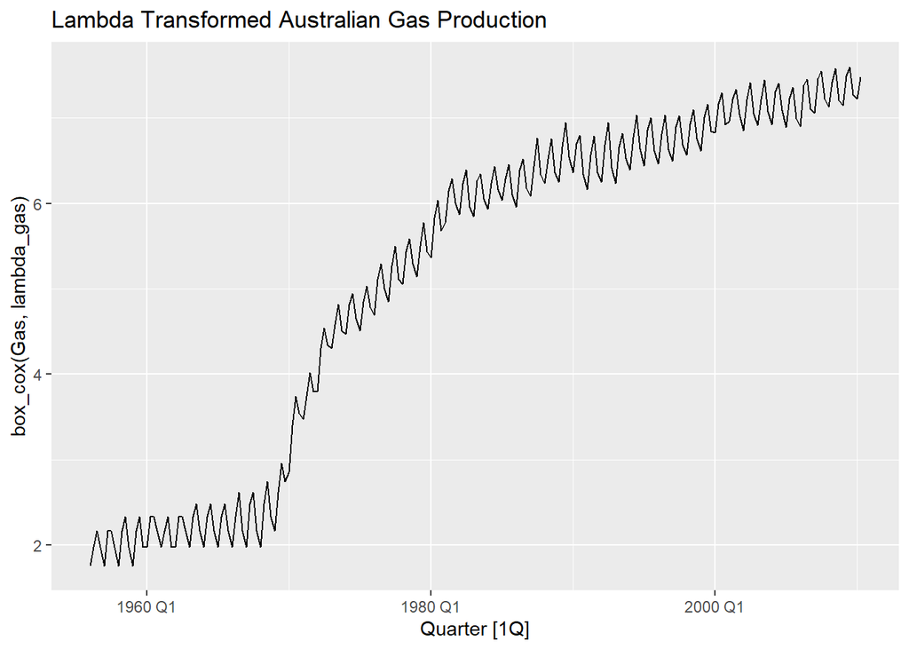

```r
lambda_gas <- aus_production %>%
  features(Gas, features = guerrero) %>%
  pull(lambda_guerrero)

aus_production %>%
  autoplot(box_cox(Gas, lambda_gas)) +
  labs(title = "Lambda Transformed Australian Gas Production")
```

The plot of Gas production from aus_production was apparent in it’s need for transformation. The beginning had way less variation than the end. In order to address this, a fitting lambda was calculated using the guerrero feature and a subsequent plot was graphed. The second plot is way more uniform in variation than the first.

## Exercise 3

Why is a Box-Cox transformation unhelpful for the canadian_gas data?

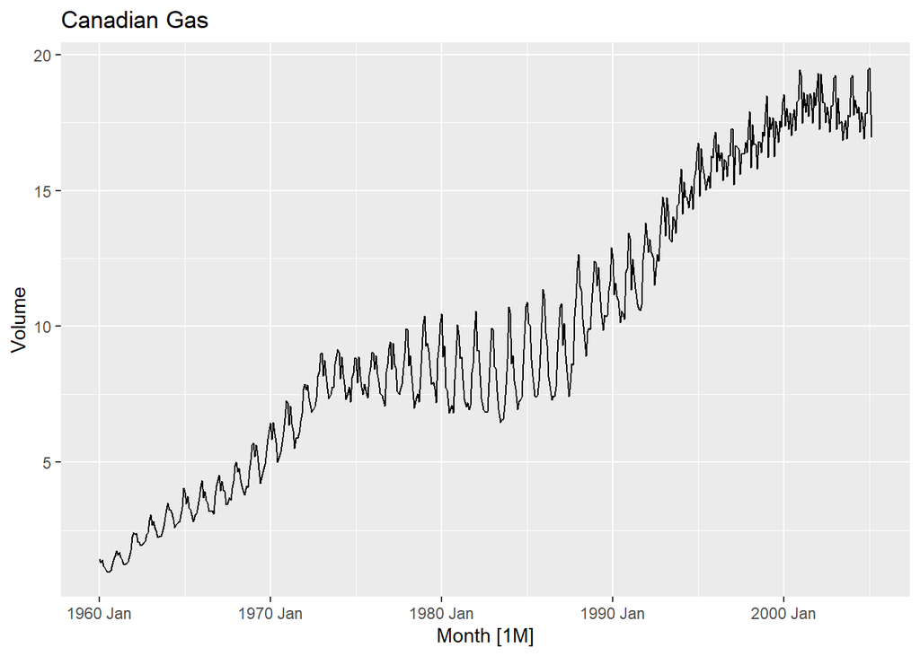

```r
autoplot(canadian_gas, Volume) +
  labs(title= "Canadian Gas")
```

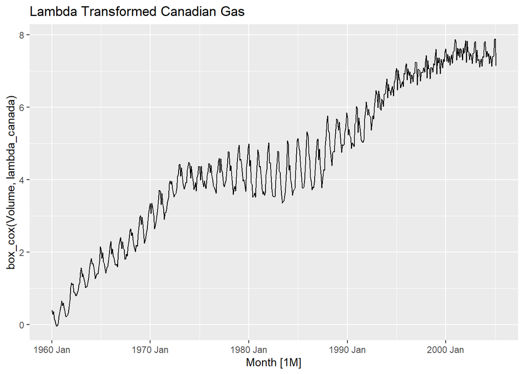

```r
lambda_canada <- canadian_gas %>%
  features(Volume, features = guerrero) %>%
  pull(lambda_guerrero)

canadian_gas %>%
  autoplot(box_cox(Volume, lambda_canada)) +
  labs(title = "Lambda Transformed Canadian Gas")
```

Box-Cox transformations seem to work by either exaggerating or minimizing already existing variations throughout a plot. This approach is perfect for graphs where there are two predominant patterns of variation within the data set and manipulation of said variation could bring them closer together. However, as is the case with the canadian_gas data, there seems to be no benefit in using Box-Cox transformations when there are more than 2 predominant patterns of variation. The canadian_gas data seems to have one variation in the first third of the data, another variation in the second, and yet another variation in the last third. Applying a Box-Cox transformation seems to squeeze in the variations without really causing them to come any closer to each other. This is to be expected since whatever transformation one chooses to perform is done to the entire data set and not just a portion.

## Exercise 4

What Box-Cox transformation would you select for your retail data (from Exercise 7 in Section 2.10)?

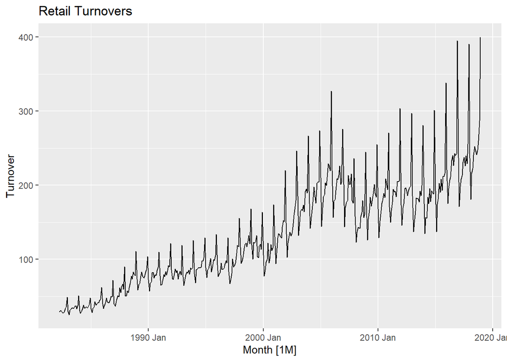

```r
set.seed(1)
myseries <- aus_retail %>%
  filter(`Series ID` == sample(aus_retail$`Series ID`,1))

autoplot(myseries, Turnover) +
  labs(title = "Retail Turnovers")
```

```r
lambda_turnover <- myseries %>%
  features(Turnover, features = guerrero) %>%
  pull(lambda_guerrero)
lambda_turnover
```

```
## [1] -0.009186879
```

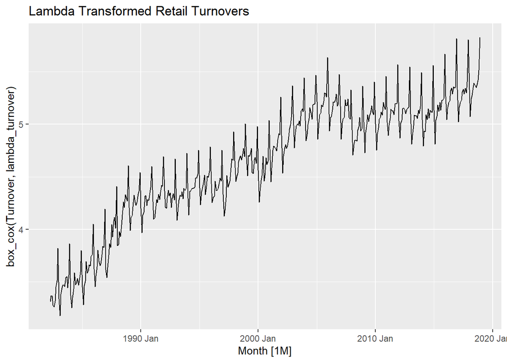

```r
myseries %>%
  autoplot(box_cox(Turnover, lambda_turnover)) +
  labs(title = "Lambda Transformed Retail Turnovers")
```

Given the preceding guerrero lambda value and plot shown above, a natural log Box-Cox transformation would be ideal. Although we obtained a lambda of -0.009, this value is much closer to 0 than it is to -1, leading to the use of natural log rather than the inverse plus one.

## Exercise 5

For the following series, find an appropriate Box-Cox transformation in order to stabilize the variance. Tobacco from aus_production, Economy class passengers between Melbourne and Sydney from ansett, and Pedestrian counts at Southern Cross Station from pedestrian.

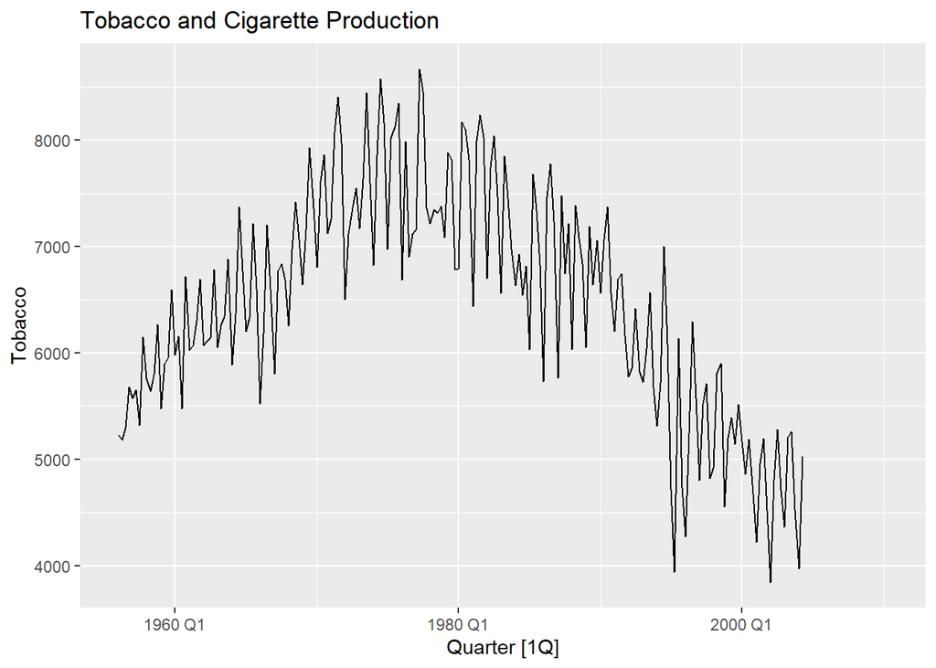

```r
autoplot(aus_production, Tobacco) +
  labs(title = "Tobacco and Cigarette Production")
```

```r
lambda_tobacco <- aus_production %>%
  features(Tobacco, features = guerrero) %>%
  pull(lambda_guerrero)
lambda_tobacco
```

```
## [1] 0.9264636
```

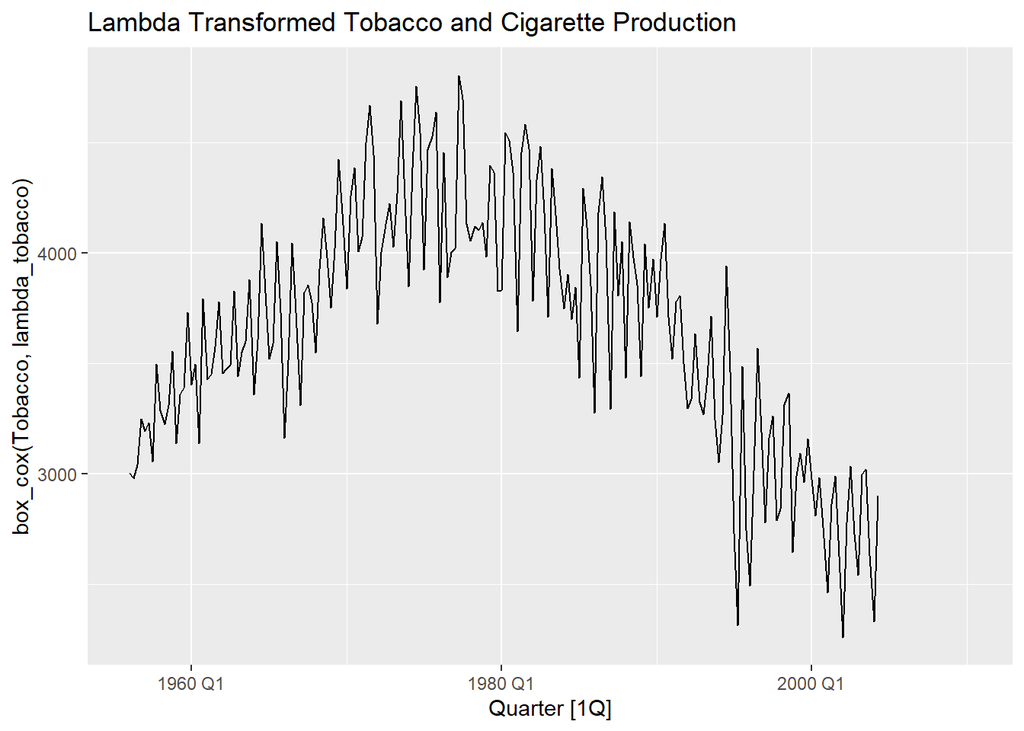

```r
aus_production %>%
  autoplot(box_cox(Tobacco, lambda_tobacco)) +
  labs(title = "Lambda Transformed Tobacco and Cigarette Production")
```

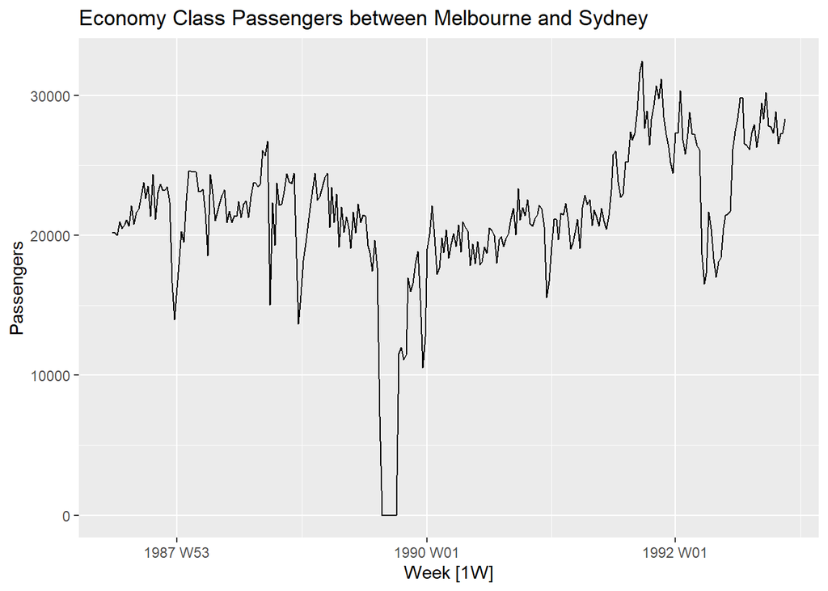

```r
autoplot(ansett %>%
           filter(Class == "Economy", Airports == "MEL-SYD"), Passengers) +
  labs(title = "Economy Class Passengers between Melbourne and Sydney")
```

```r
lambda_econ <- ansett %>%
  filter(Class == "Economy", Airports == "MEL-SYD") %>%
  features(Passengers, features = guerrero) %>%
  pull(lambda_guerrero)
lambda_econ
```

```
## [1] 1.999927
```

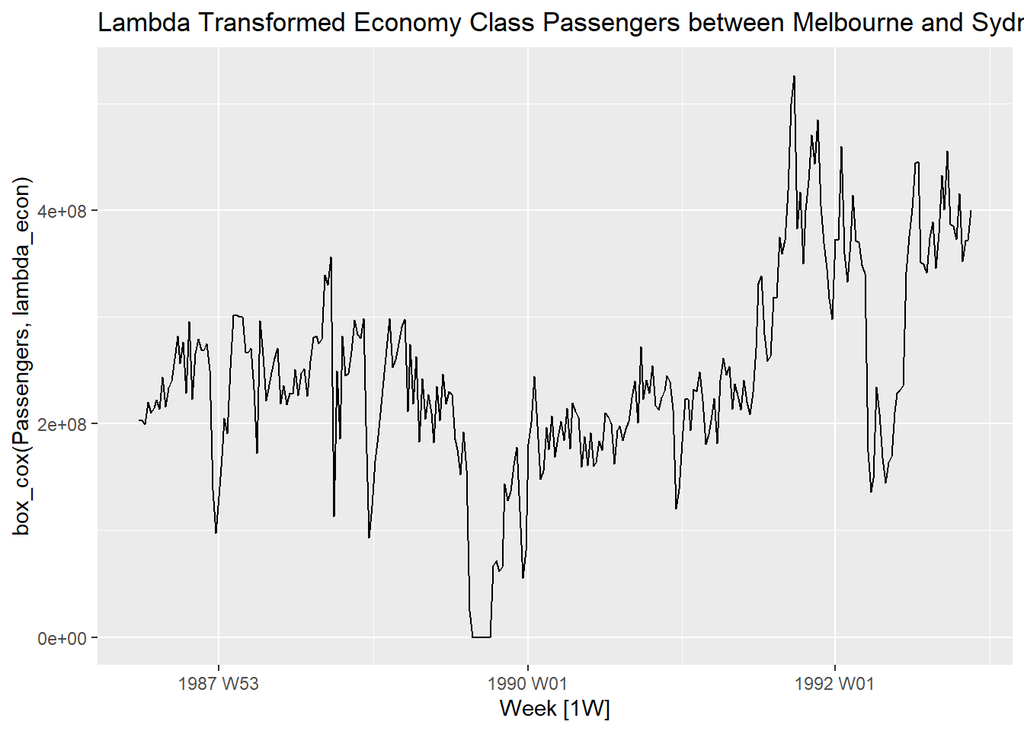

```r
ansett %>%
  filter(Class == "Economy", Airports == "MEL-SYD") %>%
  autoplot(box_cox(Passengers, lambda_econ)) +
  labs(title = "Lambda Transformed Economy Class Passengers between Melbourne and Sydney")
```

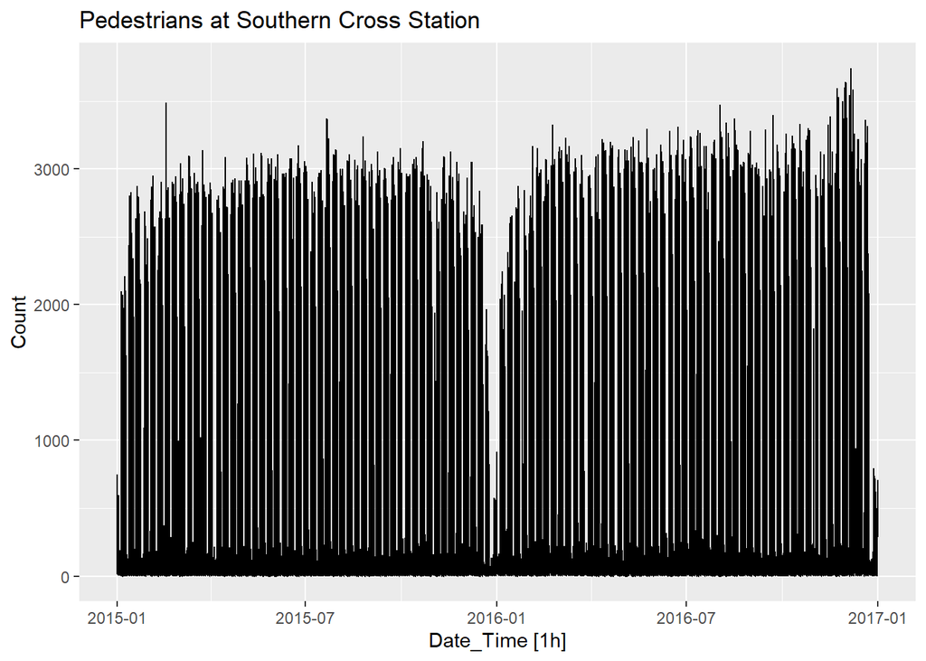

```r
autoplot(pedestrian %>%
           filter(Sensor == "Southern Cross Station"), Count) +
  labs(title = "Pedestrians at Southern Cross Station")
```

```r
lambda_ped <- pedestrian %>%
  filter(Sensor == "Southern Cross Station") %>%
  features(Count, features = guerrero) %>%
  pull(lambda_guerrero)
lambda_ped
```

```
## [1] -0.2501616
```

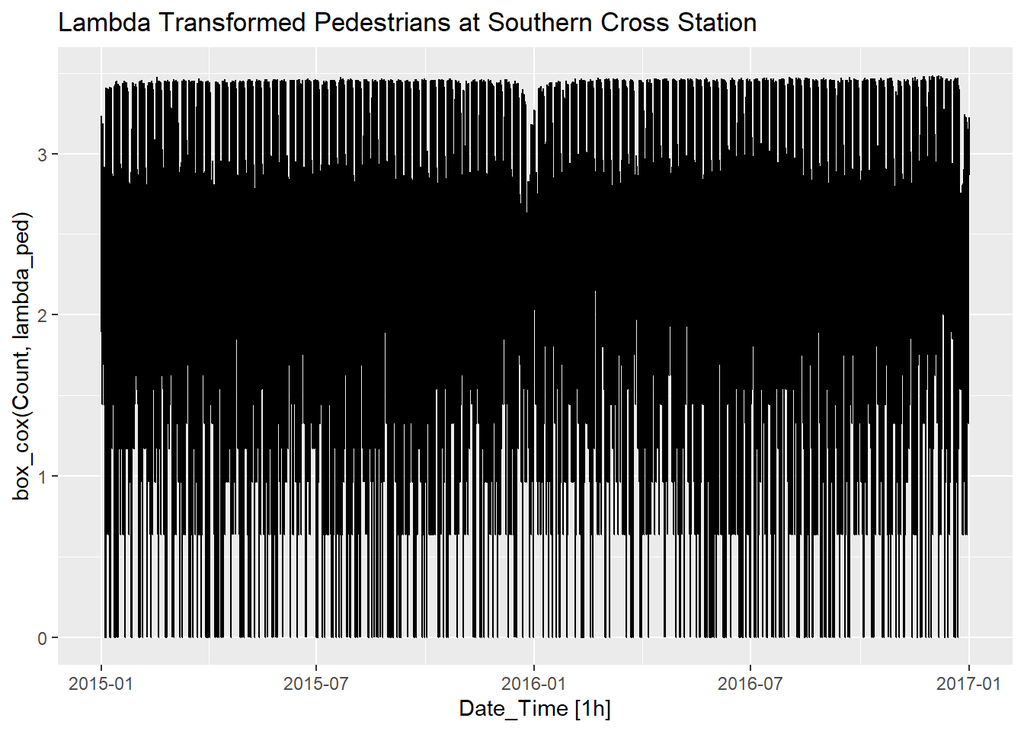

```r
pedestrian %>%
  filter(Sensor == "Southern Cross Station") %>%
  autoplot(box_cox(Count, lambda_ped)) +
  labs(title = "Lambda Transformed Pedestrians at Southern Cross Station")
```

## Exercise 7

Consider the last five years of the Gas data from aus_production.

```r
gas <- tail(aus_production, 5*4) |> select(Gas)
```

Plot the time series. Can you identify seasonal fluctuations and/or a trend-cycle? Use classical_decomposition with type=multiplicative to calculate the trend-cycle and seasonal indices. Do the results support the graphical interpretation from part a? Compute and plot the seasonally adjusted data. Change one observation to be an outlier (e.g., add 300 to one observation), and recompute the seasonally adjusted data. What is the effect of the outlier? Does it make any difference if the outlier is near the end rather than in the middle of the time series?

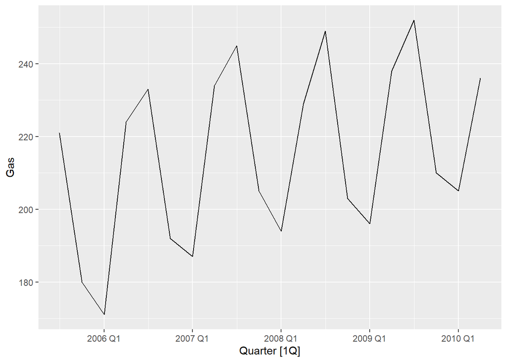

```r
autoplot(gas)
```

```r
gas %>%
  model(cd = classical_decomposition(Gas, type = "multiplicative")) %>%
  components()
```

```
## # A dable: 20 x 7 [1Q]
## # Key:     .model [1]
## # :        Gas = trend * seasonal * random
##    .model Quarter   Gas trend seasonal random season_adjust
##    <chr>    <qtr> <dbl> <dbl>    <dbl>  <dbl>         <dbl>
##  1 cd     2005 Q3   221   NA     1.13  NA              196.
##  2 cd     2005 Q4   180   NA     0.925 NA              195.
##  3 cd     2006 Q1   171  200.    0.875  0.974          195.
##  4 cd     2006 Q2   224  204.    1.07   1.02           209.
##  5 cd     2006 Q3   233  207     1.13   1.00           207.
##  6 cd     2006 Q4   192  210.    0.925  0.987          208.
##  7 cd     2007 Q1   187  213     0.875  1.00           214.
##  8 cd     2007 Q2   234  216.    1.07   1.01           218.
##  9 cd     2007 Q3   245  219.    1.13   0.996          218.
## 10 cd     2007 Q4   205  219.    0.925  1.01           222.
## 11 cd     2008 Q1   194  219.    0.875  1.01           222.
## 12 cd     2008 Q2   229  219     1.07   0.974          213.
## 13 cd     2008 Q3   249  219     1.13   1.01           221.
## 14 cd     2008 Q4   203  220.    0.925  0.996          219.
## 15 cd     2009 Q1   196  222.    0.875  1.01           224.
## 16 cd     2009 Q2   238  223.    1.07   0.993          222.
## 17 cd     2009 Q3   252  225.    1.13   0.994          224.
## 18 cd     2009 Q4   210  226     0.925  1.00           227.
## 19 cd     2010 Q1   205   NA     0.875 NA              234.
## 20 cd     2010 Q2   236   NA     1.07  NA              220.
```

Above is the resulting ‘dable’ from running the Gas data through classical decomposition with type = multiplicative. As we can see, values in the Gas field are correctly represented by the values found in the trend, seasonal, and random fields; these three fields multiplied give us what we see for their respective Gas value. This support the graphical interpretation from part a.

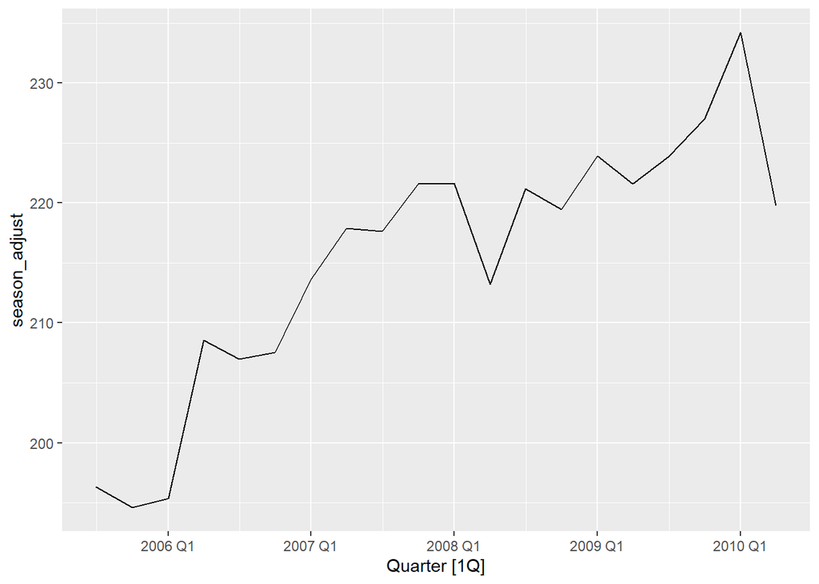

```r
gas %>%
  model(cd = classical_decomposition(Gas, type = "multiplicative")) %>%
  components() %>%
  as_tsibble() %>%
  autoplot(season_adjust)
```

The above plot is an illustration of the seasonally adjusted data. One must first convert the resulting dable into a tsibble to then be able to autoplot the season_adjust field as a time series.

```r
gas_outlier <- gas
gas_outlier$Gas[7] <- gas_outlier$Gas[7] + 300
gas_outlier %>%
  model(cd = classical_decomposition(Gas, type = "multiplicative")) %>%
  components()
```

```
## # A dable: 20 x 7 [1Q]
## # Key:     .model [1]
## # :        Gas = trend * seasonal * random
##    .model Quarter   Gas trend seasonal random season_adjust
##    <chr>    <qtr> <dbl> <dbl>    <dbl>  <dbl>         <dbl>
##  1 cd     2005 Q3   221   NA     1.04  NA              212.
##  2 cd     2005 Q4   180   NA     0.867 NA              208.
##  3 cd     2006 Q1   171  200.    1.08   0.789          158.
##  4 cd     2006 Q2   224  204.    1.01   1.09           222.
##  5 cd     2006 Q3   233  244.    1.04   0.913          223.
##  6 cd     2006 Q4   192  285.    0.867  0.776          221.
##  7 cd     2007 Q1   487  288     1.08   1.56           450.
##  8 cd     2007 Q2   234  291.    1.01   0.798          232.
##  9 cd     2007 Q3   245  256.    1.04   0.916          235.
## 10 cd     2007 Q4   205  219.    0.867  1.08           236.
## 11 cd     2008 Q1   194  219.    1.08   0.820          179.
## 12 cd     2008 Q2   229  219     1.01   1.04           227.
## 13 cd     2008 Q3   249  219     1.04   1.09           238.
## 14 cd     2008 Q4   203  220.    0.867  1.06           234.
## 15 cd     2009 Q1   196  222.    1.08   0.817          181.
## 16 cd     2009 Q2   238  223.    1.01   1.06           236.
## 17 cd     2009 Q3   252  225.    1.04   1.07           241.
## 18 cd     2009 Q4   210  226     0.867  1.07           242.
## 19 cd     2010 Q1   205   NA     1.08  NA              190.
## 20 cd     2010 Q2   236   NA     1.01  NA              234.
```

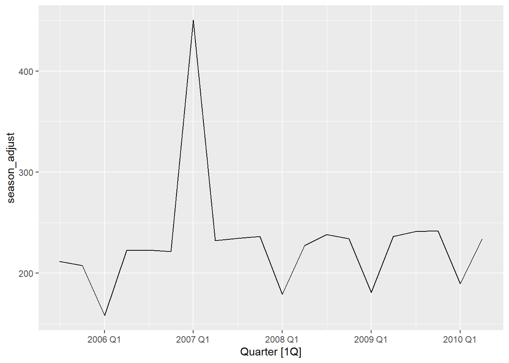

```r
gas_outlier %>%
  model(cd = classical_decomposition(Gas, type = "multiplicative")) %>%
  components() %>%
  as_tsibble() %>%
  autoplot(season_adjust)
```

```r
gas_outlier1 <- gas
gas_outlier1$Gas[20] <- gas_outlier1$Gas[20] + 300
gas_outlier1 %>%
  model(cd = classical_decomposition(Gas, type = "multiplicative")) %>%
  components()
```

```
## # A dable: 20 x 7 [1Q]
## # Key:     .model [1]
## # :        Gas = trend * seasonal * random
##    .model Quarter   Gas trend seasonal random season_adjust
##    <chr>    <qtr> <dbl> <dbl>    <dbl>  <dbl>         <dbl>
##  1 cd     2005 Q3   221   NA     1.14  NA              195.
##  2 cd     2005 Q4   180   NA     0.899 NA              200.
##  3 cd     2006 Q1   171  200.    0.883  0.966          194.
##  4 cd     2006 Q2   224  204.    1.08   1.02           207.
##  5 cd     2006 Q3   233  207     1.14   0.992          205.
##  6 cd     2006 Q4   192  210.    0.899  1.02           213.
##  7 cd     2007 Q1   187  213     0.883  0.995          212.
##  8 cd     2007 Q2   234  216.    1.08   1.00           216.
##  9 cd     2007 Q3   245  219.    1.14   0.987          216.
## 10 cd     2007 Q4   205  219.    0.899  1.04           228.
## 11 cd     2008 Q1   194  219.    0.883  1.00           220.
## 12 cd     2008 Q2   229  219     1.08   0.966          211.
## 13 cd     2008 Q3   249  219     1.14   1.00           219.
## 14 cd     2008 Q4   203  220.    0.899  1.02           226.
## 15 cd     2009 Q1   196  222.    0.883  1.00           222.
## 16 cd     2009 Q2   238  223.    1.08   0.985          220.
## 17 cd     2009 Q3   252  225.    1.14   0.986          222.
## 18 cd     2009 Q4   210  264.    0.899  0.886          233.
## 19 cd     2010 Q1   205   NA     0.883 NA              232.
## 20 cd     2010 Q2   536   NA     1.08  NA              495.
```

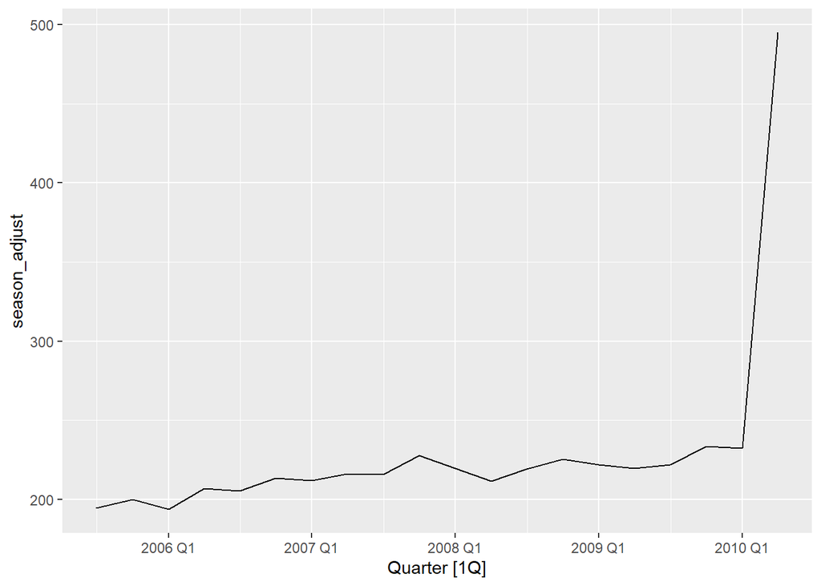

```r
gas_outlier1 %>%
  model(cd = classical_decomposition(Gas, type = "multiplicative")) %>%
  components() %>%
  as_tsibble() %>%
  autoplot(season_adjust)
```

As can be seen in the dable and plot above, the position of the outlier does seem to influence its impact on the rest of the data points. Choosing an outlier towards the ends of the data set, or plot, appears to align much better with the original data set up until the arrival of the outlier as oppose to the volatility we saw in part e.

## Exercise 8

Recall your retail time series data (from Exercise 7 in Section 2.10). Decompose the series using X-11. Does it reveal any outliers, or unusual features that you had not noticed previously?

```r
myseries %>%
  model(x11 = X_13ARIMA_SEATS(Turnover ~ x11())) %>%
  components()
```

```
## # A dable: 441 x 9 [1M]
## # Key:     State, Industry, .model [1]
## # :        Turnover = trend * seasonal * irregular
##    State      Industry         .model    Month Turnover trend seasonal irregular
##    <chr>      <chr>            <chr>     <mth>    <dbl> <dbl>    <dbl>     <dbl>
##  1 Queensland Clothing retail… x11    1982 Apr     28.9  29.1    0.963     1.03
##  2 Queensland Clothing retail… x11    1982 May     30.6  28.9    1.05      1.01
##  3 Queensland Clothing retail… x11    1982 Jun     30.5  28.8    0.966     1.10
##  4 Queensland Clothing retail… x11    1982 Jul     27.9  28.9    0.984     0.981
##  5 Queensland Clothing retail… x11    1982 Aug     27.4  29.3    0.964     0.969
##  6 Queensland Clothing retail… x11    1982 Sep     29.1  30.1    0.997     0.969
##  7 Queensland Clothing retail… x11    1982 Oct     33.4  31.2    1.04      1.03
##  8 Queensland Clothing retail… x11    1982 Nov     35.5  32.3    1.08      1.02
##  9 Queensland Clothing retail… x11    1982 Dec     48.8  33.3    1.46      1.01
## 10 Queensland Clothing retail… x11    1983 Jan     29.7  33.9    0.881     0.994
## # ℹ 431 more rows
## # ℹ 1 more variable: season_adjust <dbl>
```

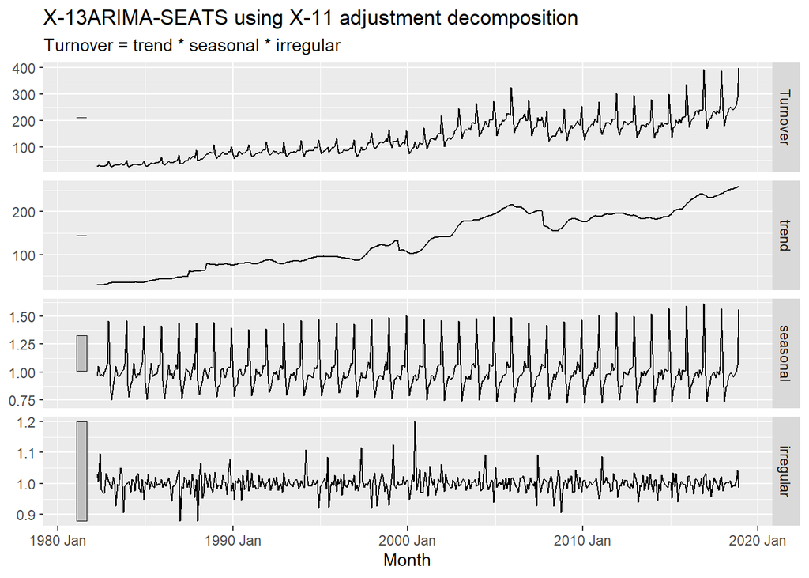

```r
myseries %>%
  model(x11 = X_13ARIMA_SEATS(Turnover ~ x11())) %>%
  components() %>%
  autoplot()
```

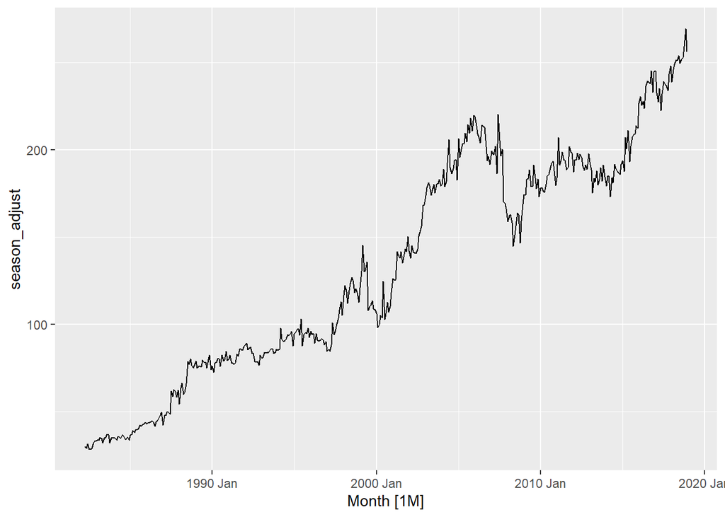

```r
myseries %>%
  model(x11 = X_13ARIMA_SEATS(Turnover ~ x11())) %>%
  components() %>%
  as_tsibble() %>%
  autoplot(season_adjust)
```

The retail time series data (from Exercise 7 in Section 2.10), also known as ‘myseries’, perfectly illustrated how the number of turnovers had an upward trend throughout the data set with only a slight downturn between the years of 2005 and 2010. The above decomposed data, however, brings to light a few inconspicuous outliers between the years 1985 and 1990 and directly after 2000 in the irregularities component. We also see that the variability in seasonality grew throughout the years and that the downturn between 2005 and 2010 appear in the trend and irregularities components. In addition, the plot for the seasonally_adjusted data also clarifies that the 1999-2001 dip seen in the irregularities was an actual downturn which would have otherwise been attributed as part of seasonality in the original plot.

## Exercise 9

[Figures 3.19 and 3.20](https://otexts.com/fpp3/decomposition-exercises.html) show the result of decomposing the number of persons in the civilian labour force in Australia each month from February 1978 to August 1995.

Write about 3–5 sentences describing the results of the decomposition. Pay particular attention to the scales of the graphs in making your interpretation. Is the recession of 1991/1992 visible in the estimated components?

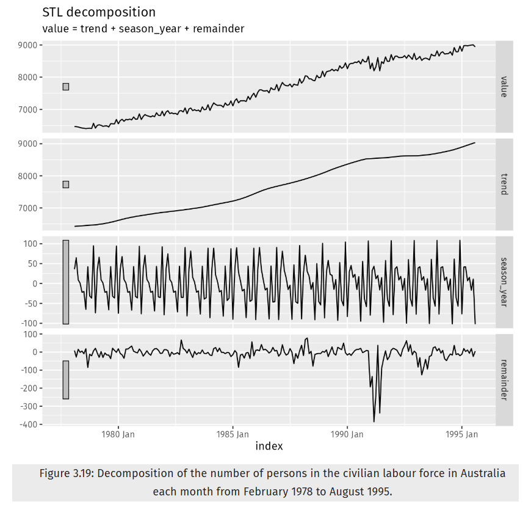

```r
knitr::include_graphics('Figure3.19.png')
```

Image 1: Chapter 3 Exercise 9 STL Decomposition (3.7 Exercises | Forecasting: Principles and Practice (3rd Ed), 2025)

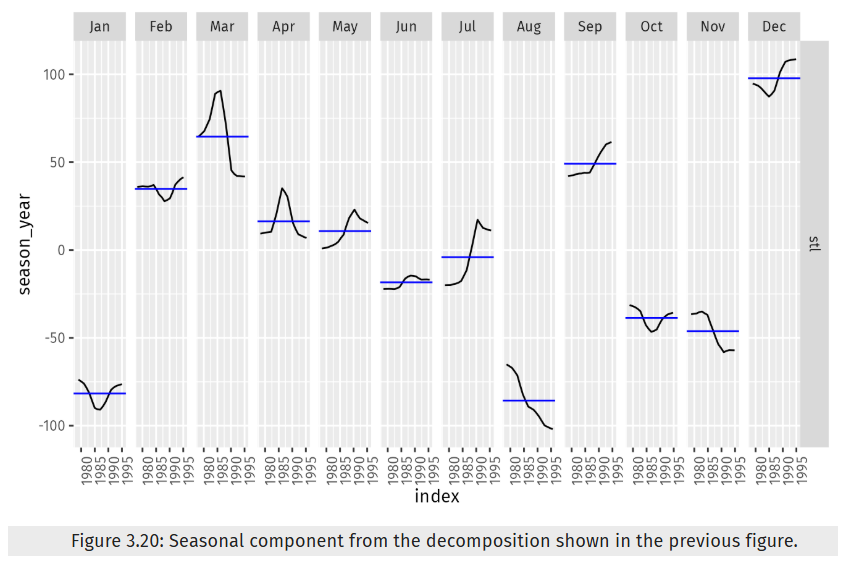

```r
knitr::include_graphics('Figure3.20.png')
```

Image 2: Chapter 3 Exercise 9 Seasonal Component (3.7 Exercises | Forecasting: Principles and Practice (3rd Ed), 2025)

Looking at the STL decomposition plots, one can see an obvious upward trend throughout the data only slightly plateauing somewhere between the years 1990 and 1995. The seasonality held the same pattern throughout the series but had an increased distance between maximums towards the final years. The remainder showed an exaggerated dip somewhere between 1990 and 1992.

## Works Cited

3.7 Exercises | Forecasting: Principles and Practice (3rd ed). (2025). Otexts.com. https://otexts.com/fpp3/decomposition-exercises.html